# 3

SeoYeonYang

2018년 10월 19일

# Lecture 4. Exploratory Data Analysis

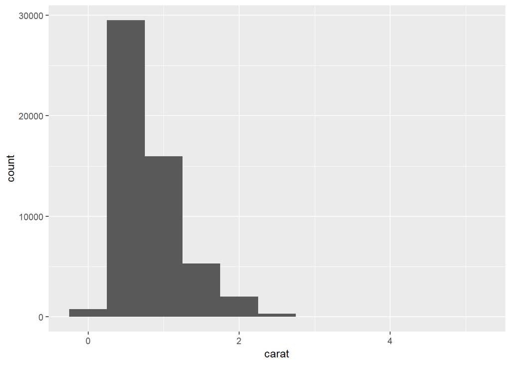

```r
#연속변수를 단위로 잘라 히스토그램 그리기
ggplot(data = diamonds) +
  geom_histogram(mapping = aes(x = carat), binwidth = 0.5)
```

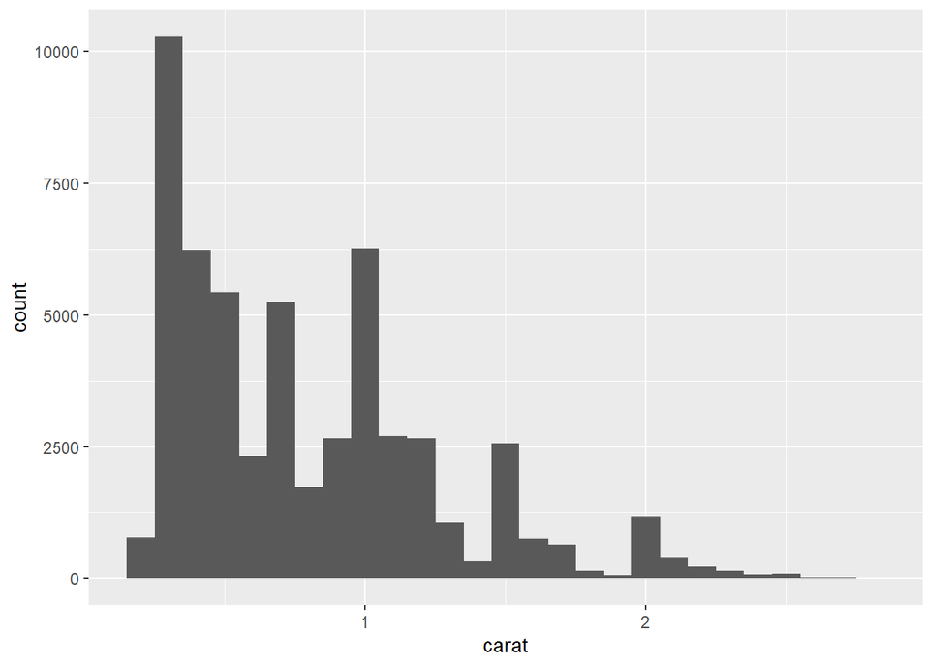

```r
smaller <- diamonds %>%
  filter(carat < 3)  # zoom into just the diamonds with a size of less than three carats
ggplot(data = smaller, mapping = aes(x = carat)) + geom_histogram(binwidth = 0.1)
```

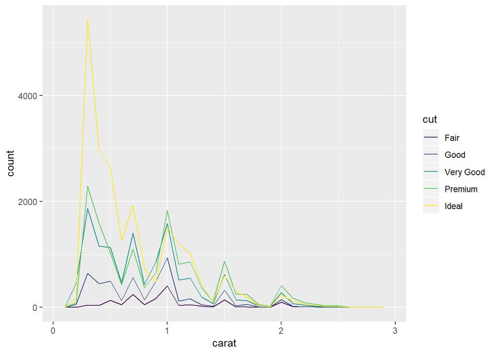

```r
ggplot(data = smaller, mapping = aes(x = carat, colour = cut)) +
  geom_freqpoly(binwidth = 0.1)     # use geom_freqploy() instead of geom_histogram()
```

**outlier**! 데이터 입력 에러(이거나, 엄청난 발견이거나)  
1. Repeat your analysis with and without the outliers.  
2. outlier가 결과에 미미한 영향을 끼치고, 그 값이 왜 있는지 알 수 없다면 missing value로 처리하는 것이 합리적이다.  
3. 그렇지 않다면, you shouldn’t drop them without justification. 왜 그것이 거기에 있는지 찾고(e.g. a data entry error), 그것을 제거했음을 명시해야 한다.

### Replacing the unusual values with missing values.

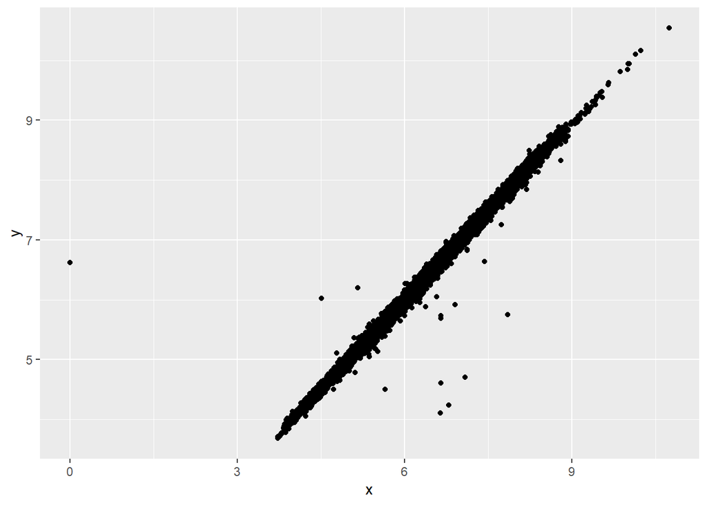

```r
#ifelse() : 1. logical vector. 2. 1에 대해 yes면 여기에 저장. 3. no면 여기에 저장
diamonds2 <- diamonds %>%
      mutate(y = ifelse(y < 3 | y > 20, NA, y))
ggplot(data = diamonds2, mapping = aes(x = x, y = y)) +
  geom_point()
```

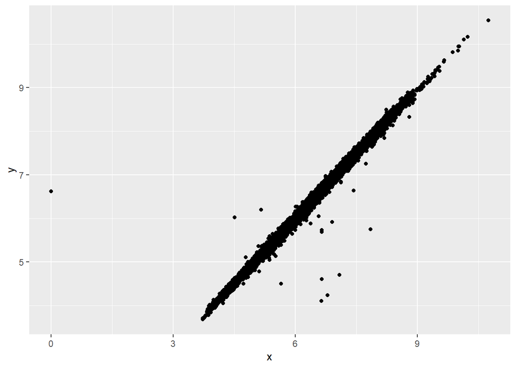

```r
#Warning: Removed 9 rows containing missing values (geom_point).
#경고문 없애려면
ggplot(data = diamonds2, mapping = aes(x = x, y = y)) +
  geom_point(na.rm = TRUE)
```

### Compare the scheduled departure times for cancelled and non-cancelled times

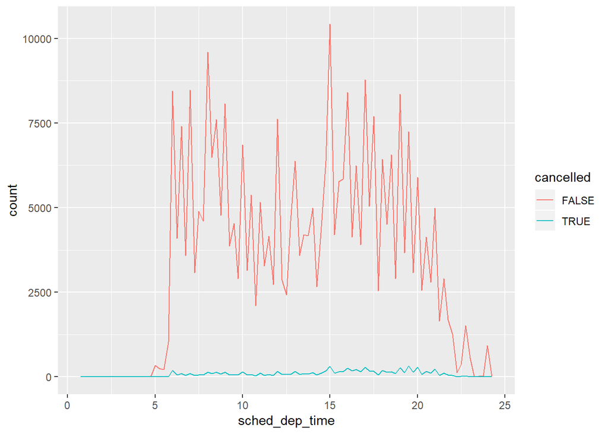

```r
nycflights13::flights %>%
  mutate(
    cancelled = is.na(dep_time),
    sched_hour = sched_dep_time %/% 100,
    sched_min = sched_dep_time %% 100,
    sched_dep_time = sched_hour + sched_min / 60
  ) %>%
  ggplot(mapping = aes(sched_dep_time)) +
    geom_freqpoly(mapping = aes(colour = cancelled), binwidth = 1/4)
```

###count대신 비율로 그리기

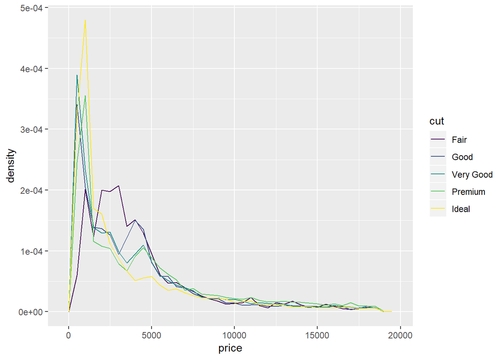

```r
#x축에 따라서. 가격이 1-10인거는 0.3 있고 10-20은 0.2 있고 이런식으로. 그런데 color=cut을 주면 그걸 cut별로 그려낸다
ggplot(data = diamonds,
       mapping = aes(x = price, y = ..density..)) +
  geom_freqpoly(mapping = aes(colour = cut), binwidth = 500)
```

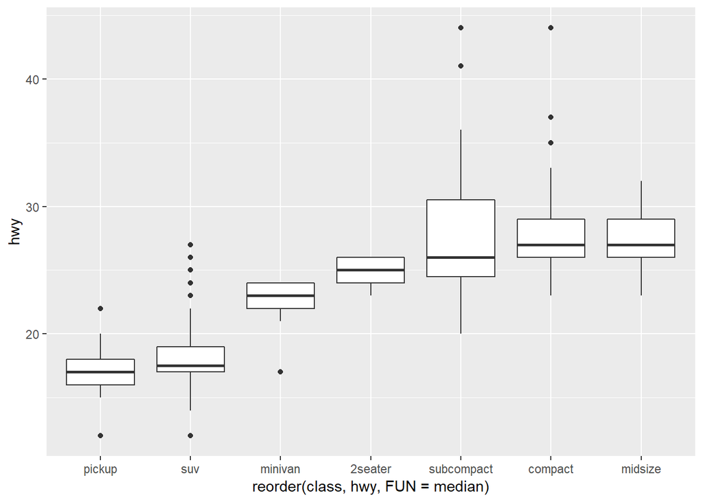

```r
# reorder `class` based on the median value of `hwy`
ggplot(data = mpg) +
  geom_boxplot(mapping = aes(x = reorder(class, hwy, FUN = median), y = hwy))
```

### Two categorical variables

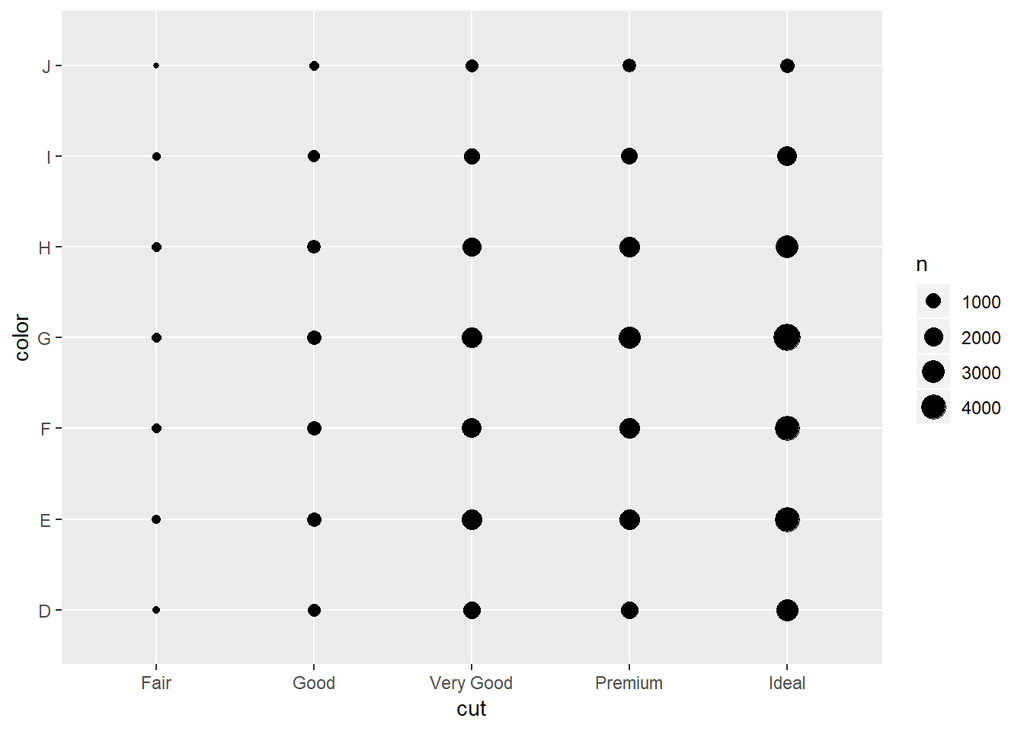

```r
#두 categorical 변수 cut-color의 조합이 많을수록 점의 크기가 크게 나타남.
ggplot(data = diamonds) +
  geom_count(mapping = aes(x = cut, y = color))
```

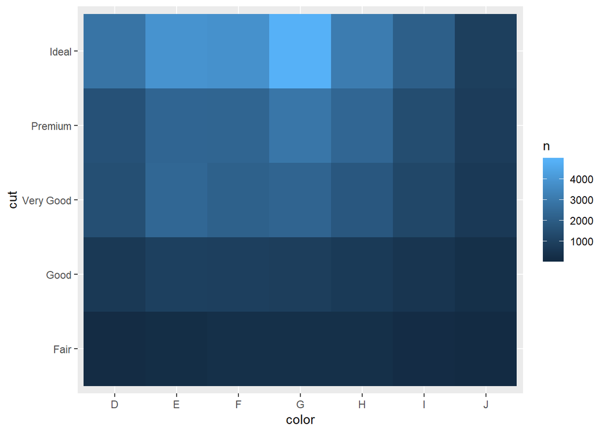

```r
#개수(n)에 따라 밝은게 많고 어두운게 적은걸로 색깔을 채움
diamonds %>%
  count(color, cut) %>%
  ggplot(mapping = aes(x = color, y = cut)) +
    geom_tile(mapping = aes(fill = n))
```

###Two continuous variables

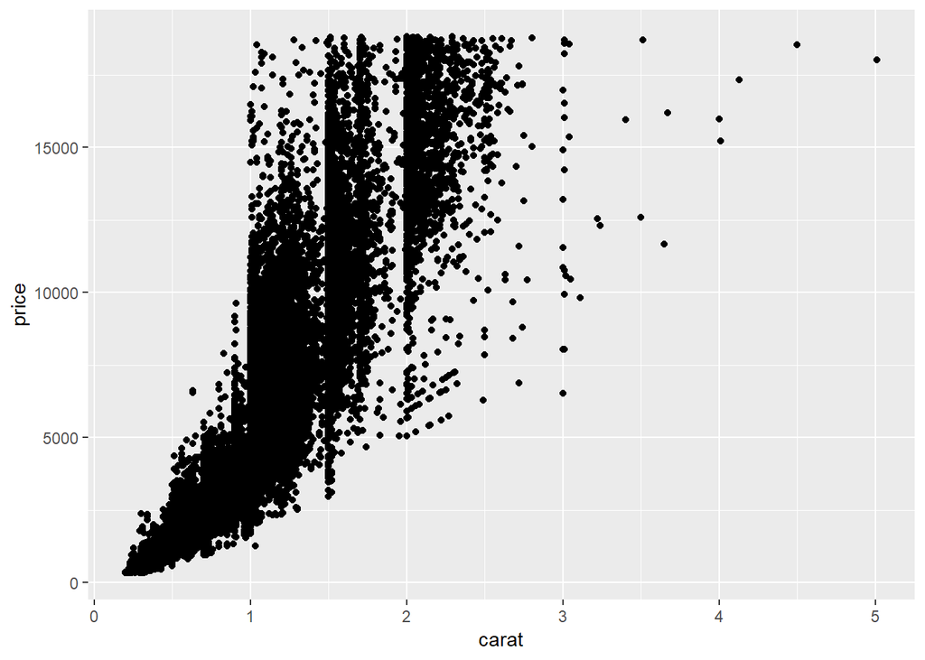

```r
#scatter plot
ggplot(data = diamonds) +
  geom_point(mapping = aes(x = carat, y = price))
```

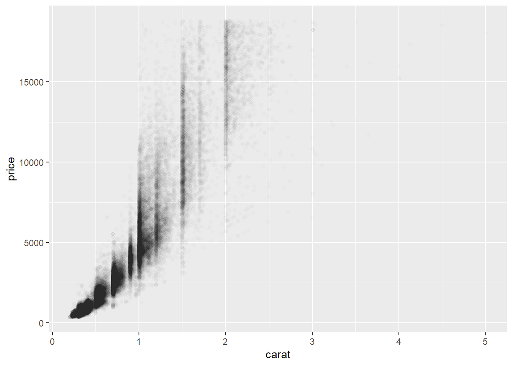

```r
#Large-size data, use alpha(투명도 조절). 역시나 1, 1.5, 2캐럿에서 진한 줄이 보인다.
ggplot(data = diamonds) +
  geom_point(mapping = aes(x = carat, y = price), alpha = 1 / 100)
```

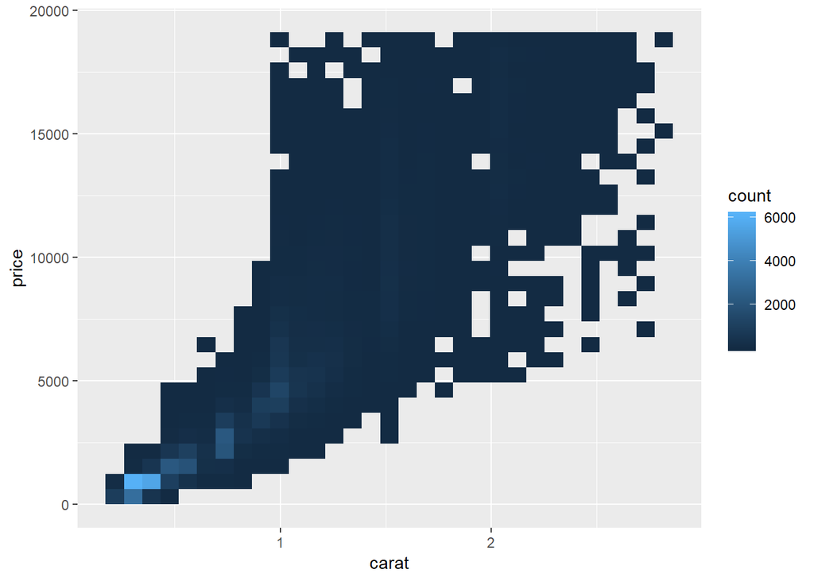

```r
#alpha는 진하기로 조절했다면 bin2d함수는 색깔로 조절해서 보여줌.(어두운색-밝은색)
ggplot(data = smaller) +
  geom_bin2d(mapping = aes(x = carat, y = price))
```

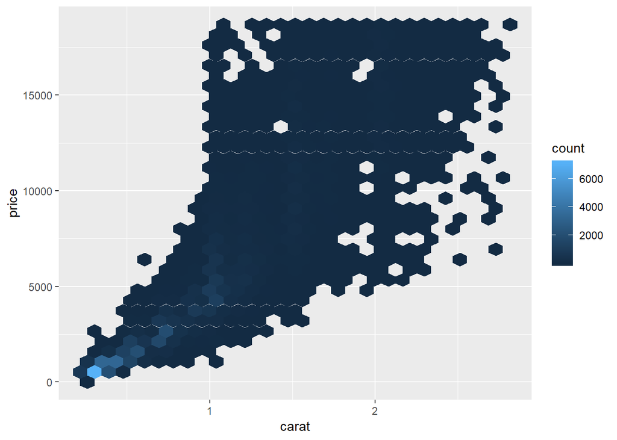

```r
# library(hexbin)
# bin2d는 사각형으로, hex는 육각형으로 그림을 그림
ggplot(data = smaller) +
  geom_hex(mapping = aes(x = carat, y = price))
```

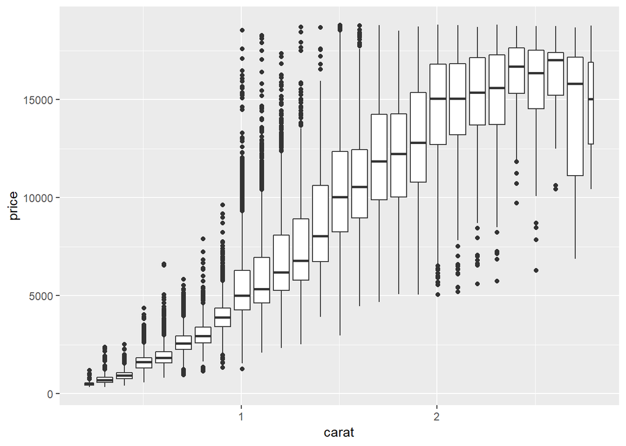

```r
# carat은 continuos 변수이지만 cut_witdth를 이용해 categorical처럼 사용 가능
ggplot(data = smaller, mapping = aes(x = carat, y = price)) +
  geom_boxplot(mapping = aes(group = cut_width(carat, width=0.1)))
```

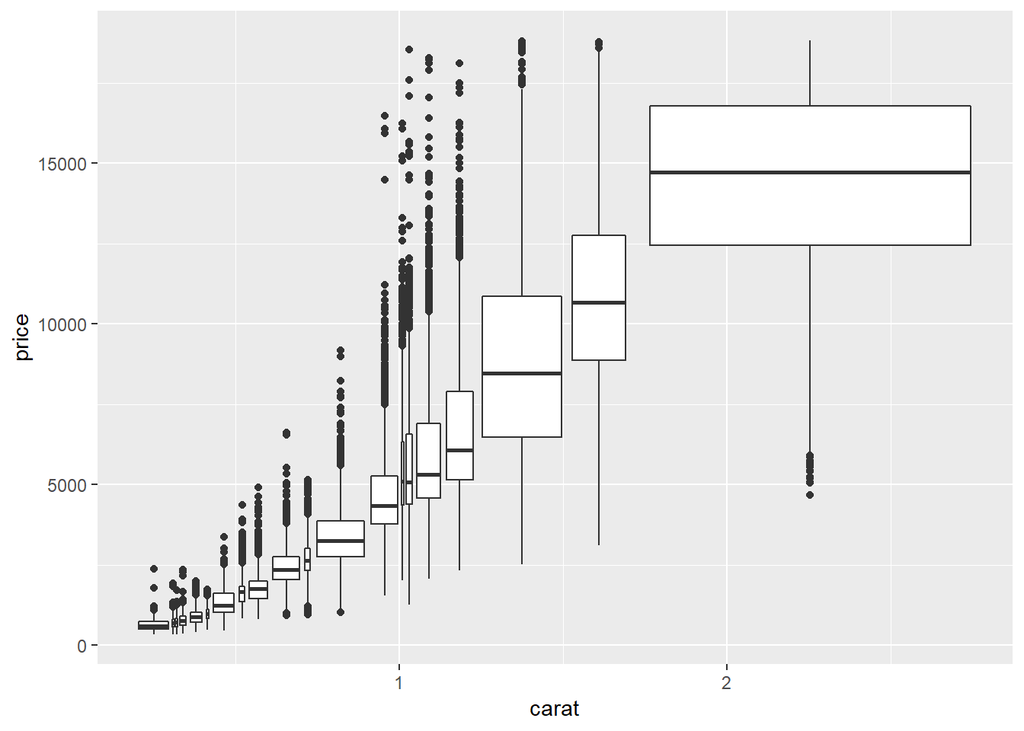

```r
# approximately the same number of points in each bin
ggplot(data = smaller, mapping = aes(x = carat, y = price)) +
  geom_boxplot(mapping = aes(group = cut_number(carat, n=20)))
```

If a systematic relationship exists between two variables it will appear as a pattern in the data. If you spot a pattern, ask yourself:  
1. 이 패턴이 우연에 의한 것인가?  
2. 이 패턴에 의한 관계를 어떻게 기술할 수 있을까?  
3. 이 패턴이 얼마나 강한가?  
4. 다른 변수는 이 관계에 어떤 영향을 끼치겠는가?  
5. subgroup으로 확대해서 보면 다른 관계를 찾을 수 있을까?

### Models extract patterns out of data

diamonds에서 cur-carat, price-carat의 강한 관계 때문에 cut-price의 관계를 관찰하기 힘들다.  
-> price-carat의 강한 관계를 제거한 나머지에서 관찰이 가능하다!

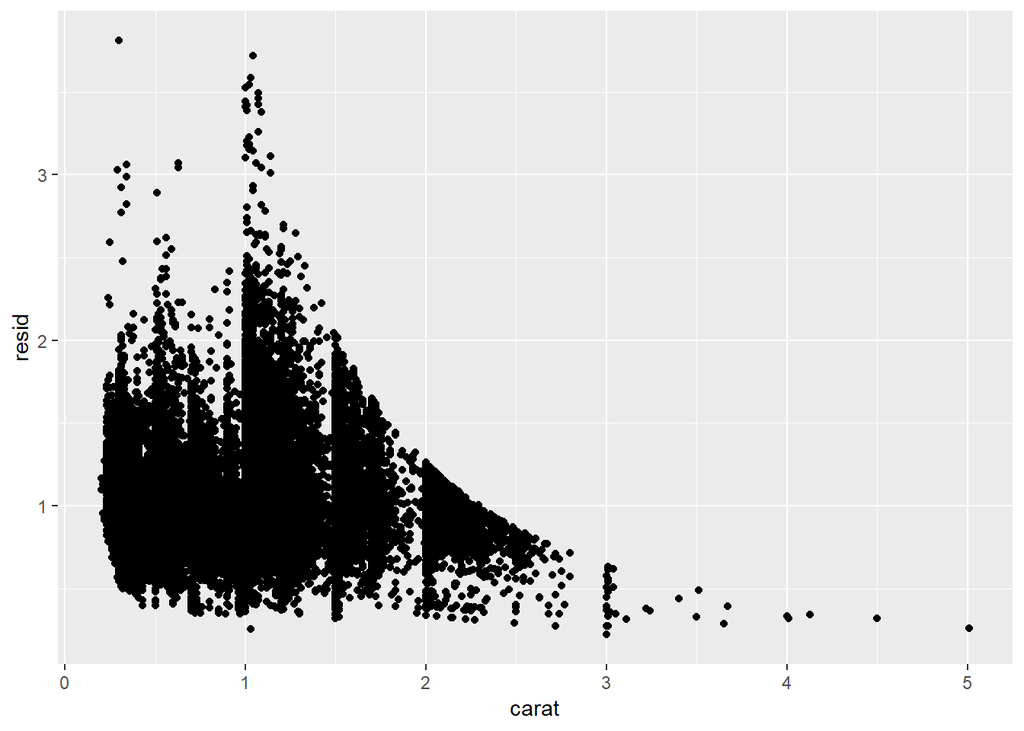

```r
# library(modelr)
# assume exponential relation between `price` and `carat`
mod <- lm(log(price) ~ log(carat), data = diamonds)  #lm : 선형회귀

diamonds2 <- diamonds %>%
  add_residuals(mod) %>%    #pirce에서 carat의 영향 제거
  mutate(resid = exp(resid))  # residuals of the model

ggplot(data = diamonds2) +
  geom_point(mapping = aes(x = carat, y = resid))
```

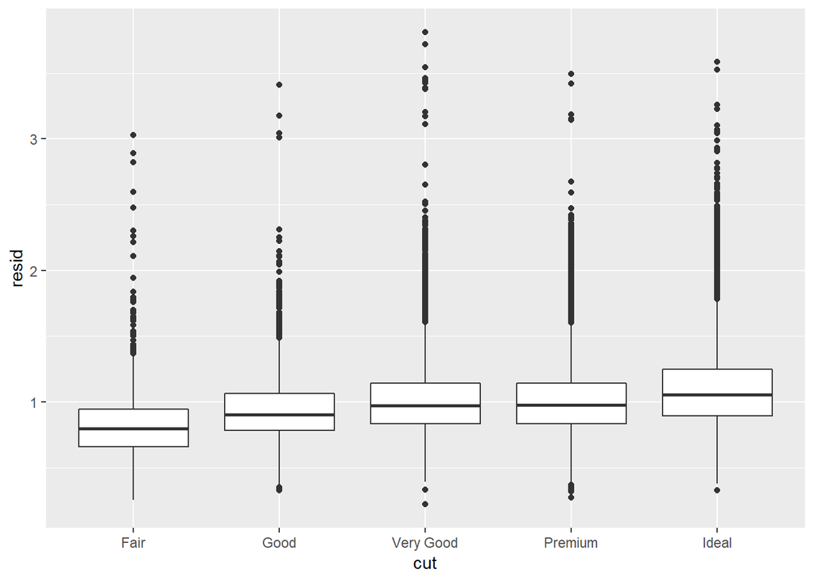

```r
#Ideal의 가격이 가장 높게 나온다.
ggplot(data = diamonds2) +
  geom_boxplot(mapping = aes(x = cut, y = resid))
```